# Sym_Flow

```r
head(go_input_DvsA)
```

```
##                 isogroup mutated_p_updown
## 1 TRINITY_GG_10000_c0_g1       0.15236082
## 2 TRINITY_GG_10001_c0_g1      -2.09534386
## 3 TRINITY_GG_10002_c0_g1      -3.21061124
## 4 TRINITY_GG_10003_c0_g1      -1.08132158
## 5 TRINITY_GG_10004_c0_g1      -0.48062273
## 6 TRINITY_GG_10005_c0_g1      -0.02537298
```

```r
nrow(go_input_DvsA)
```

```
## [1] 22381
```

```r
colnames(go_input_DvsA) <- c("gene", "pval")
head(go_input_DvsA)
```

```
##                     gene        pval
## 1 TRINITY_GG_10000_c0_g1  0.15236082
## 2 TRINITY_GG_10001_c0_g1 -2.09534386
## 3 TRINITY_GG_10002_c0_g1 -3.21061124
## 4 TRINITY_GG_10003_c0_g1 -1.08132158
## 5 TRINITY_GG_10004_c0_g1 -0.48062273
## 6 TRINITY_GG_10005_c0_g1 -0.02537298
```

```r
write.csv(go_input_DvsA, file="DvsA_GO.csv", quote=F, row.names=FALSE)

#################### D vs B
colData$DvsB<-factor(colData$treat, levels=c("Cond_D","Cond_B"))
##second term is the "control"
resDvsB <- results(dds, contrast=c("treat","Cond_D","Cond_B"))
#how many FDR < 10%?
table(resDvsB$padj<0.1)
```

```
##
## FALSE  TRUE
##  6959  2851
```

```r
table(resDvsB$padj<0.05)
```

```
##
## FALSE  TRUE
##  8297  1513
```

```r
table(resDvsB$padj<0.01)
```

```
##
## FALSE  TRUE
##  9516   294
```

```r
# 0.1=1886
# 0.05=1009
# 0.01=187
summary(resDvsB)
```

```
##
## out of 22425 with nonzero total read count
## adjusted p-value < 0.1
## LFC > 0 (up)       : 254, 1.1%
## LFC < 0 (down)     : 2597, 12%
## outliers [1]       : 44, 0.2%
## low counts [2]     : 12571, 56%
## (mean count < 2)
## [1] see 'cooksCutoff' argument of ?results
## [2] see 'independentFiltering' argument of ?results
```

```r
nrow(resDvsB[resDvsB$padj<0.05 & !is.na(resDvsB$padj),])  # Num significantly differentially expressed genes excluding the no/low count genes   #228
```

```
## [1] 1513
```

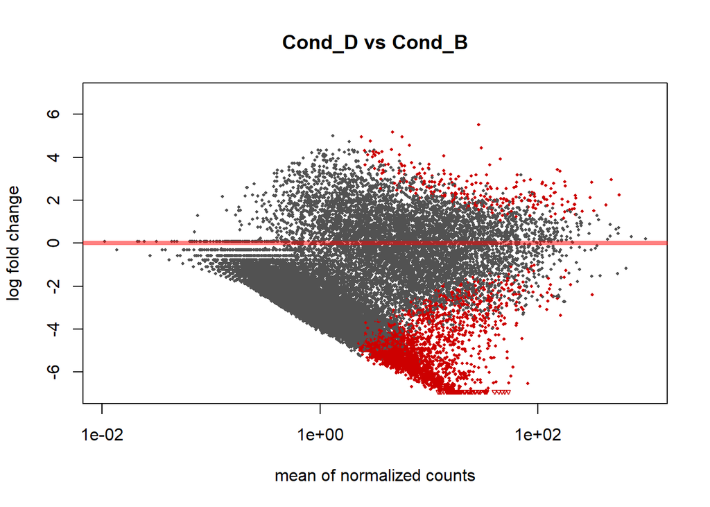

```r
plotMA(resDvsB, main="Cond_D vs Cond_B")
```

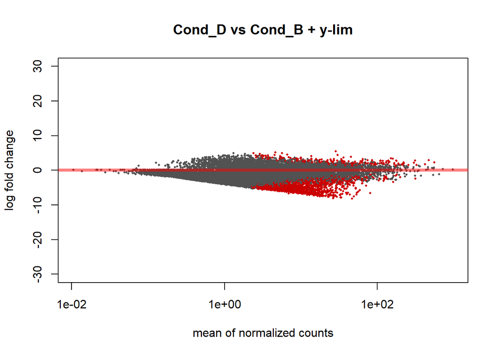

```r
plotMA(resDvsB, main="Cond_D vs Cond_B + y-lim", ylim=c(-30,30))
```

```r
results <- as.data.frame(resDvsB)
head(results)
```

```
##                          baseMean log2FoldChange    lfcSE       stat
## TRINITY_GG_10000_c0_g1 3.82970439      -0.163707 1.318921 -0.1241219
## TRINITY_GG_10001_c0_g1 1.45182244      -4.109516 2.042977 -2.0115330
## TRINITY_GG_10002_c0_g1 4.50386174      -3.700295 1.744277 -2.1213916
## TRINITY_GG_10003_c0_g1 1.70258343      -3.109764 2.490744 -1.2485279
## TRINITY_GG_10004_c0_g1 0.48633492      -2.177585 3.548538 -0.6136569
## TRINITY_GG_10005_c0_g1 0.09315756      -1.094686 4.519321 -0.2422236
##                            pvalue      padj
## TRINITY_GG_10000_c0_g1 0.90121875 0.9439415
## TRINITY_GG_10001_c0_g1 0.04426918        NA
## TRINITY_GG_10002_c0_g1 0.03388887 0.1081137
## TRINITY_GG_10003_c0_g1 0.21183778        NA
## TRINITY_GG_10004_c0_g1 0.53944209        NA
## TRINITY_GG_10005_c0_g1 0.80860691        NA
```

```r
nrow(resAvsB[resDvsB$padj<0.1 & resDvsB$log2FoldChange > 0 & !is.na(resDvsB$padj),])
```

```
## [1] 254
```

```r
nrow(resAvsB[resDvsB$padj<0.1 & resDvsB$log2FoldChange < 0 & !is.na(resDvsB$padj),])
```

```
## [1] 2597
```

```r
#UP in D = 217
#DOWN in D = 1669

write.table(resDvsB, file="DvsB.txt", quote=F, sep="\t")

cd <- read.table("DvsB.txt")
##Delete outliers log2fold >10##
cd<-cd[!rowSums(cd[2] >10),]
head(cd)
```

```
##                          baseMean log2FoldChange    lfcSE       stat
## TRINITY_GG_10000_c0_g1 3.82970439      -0.163707 1.318921 -0.1241219
## TRINITY_GG_10001_c0_g1 1.45182244      -4.109516 2.042977 -2.0115330
## TRINITY_GG_10002_c0_g1 4.50386174      -3.700295 1.744277 -2.1213916
## TRINITY_GG_10003_c0_g1 1.70258343      -3.109764 2.490744 -1.2485279
## TRINITY_GG_10004_c0_g1 0.48633492      -2.177585 3.548538 -0.6136569
## TRINITY_GG_10005_c0_g1 0.09315756      -1.094686 4.519321 -0.2422236
##                            pvalue      padj
## TRINITY_GG_10000_c0_g1 0.90121875 0.9439415
## TRINITY_GG_10001_c0_g1 0.04426918        NA
## TRINITY_GG_10002_c0_g1 0.03388887 0.1081137
## TRINITY_GG_10003_c0_g1 0.21183778        NA
## TRINITY_GG_10004_c0_g1 0.53944209        NA
## TRINITY_GG_10005_c0_g1 0.80860691        NA
```

```
##                          baseMean log2FoldChange    lfcSE       stat
## TRINITY_GG_10000_c0_g1  1.9372330      -0.163707 1.318921 -0.1241219
## TRINITY_GG_10001_c0_g1  0.5378650      -4.109516 2.042977 -2.0115330
## TRINITY_GG_10002_c0_g1  2.1711625      -3.700295 1.744277 -2.1213916
## TRINITY_GG_10003_c0_g1  0.7677255      -3.109764 2.490744 -1.2485279
## TRINITY_GG_10004_c0_g1 -1.0399779      -2.177585 3.548538 -0.6136569
## TRINITY_GG_10005_c0_g1 -3.4241834      -1.094686 4.519321 -0.2422236
##                            pvalue      padj dotcol
## TRINITY_GG_10000_c0_g1 0.90121875 0.9439415  black
## TRINITY_GG_10001_c0_g1 0.04426918        NA   <NA>
## TRINITY_GG_10002_c0_g1 0.03388887 0.1081137  black
## TRINITY_GG_10003_c0_g1 0.21183778        NA   <NA>
## TRINITY_GG_10004_c0_g1 0.53944209        NA   <NA>
## TRINITY_GG_10005_c0_g1 0.80860691        NA   <NA>
```

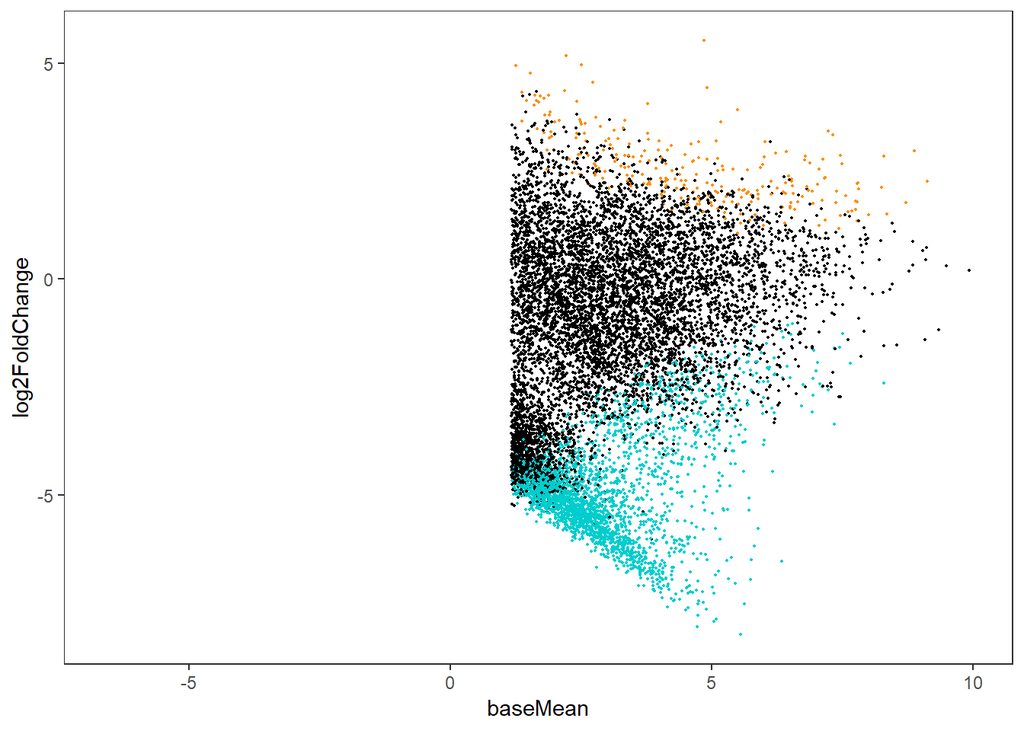

```r
MAttPlot(cd)
```

```r
##########make the GO table for MWU
head(cd)
```

```
##                          baseMean log2FoldChange    lfcSE       stat
## TRINITY_GG_10000_c0_g1 3.82970439      -0.163707 1.318921 -0.1241219
## TRINITY_GG_10001_c0_g1 1.45182244      -4.109516 2.042977 -2.0115330
## TRINITY_GG_10002_c0_g1 4.50386174      -3.700295 1.744277 -2.1213916
## TRINITY_GG_10003_c0_g1 1.70258343      -3.109764 2.490744 -1.2485279
## TRINITY_GG_10004_c0_g1 0.48633492      -2.177585 3.548538 -0.6136569
## TRINITY_GG_10005_c0_g1 0.09315756      -1.094686 4.519321 -0.2422236
##                            pvalue      padj
## TRINITY_GG_10000_c0_g1 0.90121875 0.9439415
## TRINITY_GG_10001_c0_g1 0.04426918        NA
## TRINITY_GG_10002_c0_g1 0.03388887 0.1081137
## TRINITY_GG_10003_c0_g1 0.21183778        NA
## TRINITY_GG_10004_c0_g1 0.53944209        NA
## TRINITY_GG_10005_c0_g1 0.80860691        NA
```

```r
cd$isogroup=row.names(cd)
library(dplyr)
go_input_DvsB = cd %>%
  mutate(mutated_p = -log(pvalue)) %>%
  mutate(mutated_p_updown = ifelse(log2FoldChange < 0, mutated_p*-1, mutated_p*1)) %>%
  select(isogroup, mutated_p_updown) %>%
  na.omit()

nrow(go_input_DvsB)
```

```
## [1] 22381
```

```r
head(go_input_DvsB)
```

```
##                 isogroup mutated_p_updown
## 1 TRINITY_GG_10000_c0_g1       -0.1040073
## 2 TRINITY_GG_10001_c0_g1       -3.1174665
## 3 TRINITY_GG_10002_c0_g1       -3.3846688
## 4 TRINITY_GG_10003_c0_g1       -1.5519345
## 5 TRINITY_GG_10004_c0_g1       -0.6172198
## 6 TRINITY_GG_10005_c0_g1       -0.2124424
```

```r
nrow(go_input_DvsB)
```

```
## [1] 22381
```

```r
colnames(go_input_DvsB) <- c("gene", "pval")
head(go_input_DvsB)
```

```
##                     gene       pval
## 1 TRINITY_GG_10000_c0_g1 -0.1040073
## 2 TRINITY_GG_10001_c0_g1 -3.1174665
## 3 TRINITY_GG_10002_c0_g1 -3.3846688
## 4 TRINITY_GG_10003_c0_g1 -1.5519345
## 5 TRINITY_GG_10004_c0_g1 -0.6172198
## 6 TRINITY_GG_10005_c0_g1 -0.2124424
```

```r
write.csv(go_input_DvsB, file="DvsB_GO.csv", quote=F, row.names=FALSE)


#################### D vs C
colData$DvsC<-factor(colData$treat, levels=c("Cond_D","Cond_C"))
##second term is the "control"
resDvsC <- results(dds, contrast=c("treat","Cond_D","Cond_C"))
#how many FDR < 10%?
table(resDvsC$padj<0.1)
```

```
##
## FALSE  TRUE
##  6890  1184
```

```r
table(resDvsC$padj<0.05)
```

```
##
## FALSE  TRUE
##  7544   530
```

```r
table(resDvsC$padj<0.01)
```

```
##
## FALSE  TRUE
##  8057    17
```

```r
# 0.1= 682
# 0.05= 564
# 0.01=369
summary(resDvsC)
```

```
##
## out of 22425 with nonzero total read count
## adjusted p-value < 0.1
## LFC > 0 (up)       : 24, 0.11%
## LFC < 0 (down)     : 1160, 5.2%
## outliers [1]       : 44, 0.2%
## low counts [2]     : 14307, 64%
## (mean count < 3)
## [1] see 'cooksCutoff' argument of ?results
## [2] see 'independentFiltering' argument of ?results
```

```r
nrow(resDvsC[resDvsC$padj<0.05 & !is.na(resDvsC$padj),])  # Num significantly differentially expressed genes excluding the no/low count genes   #228
```

```
## [1] 530
```

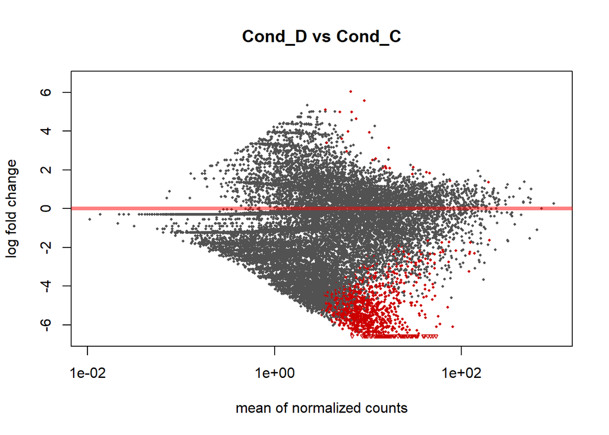

```r
plotMA(resDvsC, main="Cond_D vs Cond_C")
```

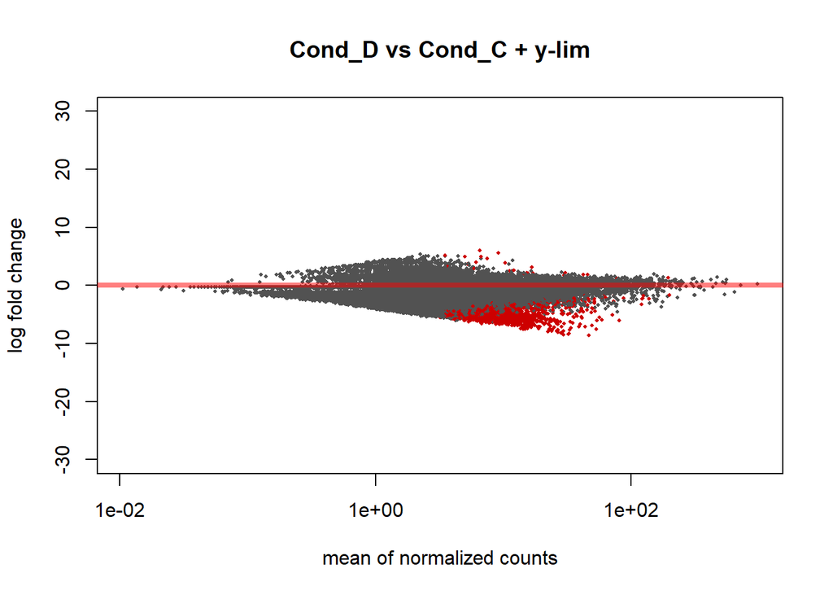

```r
plotMA(resDvsC, main="Cond_D vs Cond_C + y-lim", ylim=c(-30,30))
```

```r
results <- as.data.frame(resDvsC)
head(results)
```

```
##                          baseMean log2FoldChange    lfcSE        stat
## TRINITY_GG_10000_c0_g1 3.82970439      1.6556872 1.431288  1.15678139
## TRINITY_GG_10001_c0_g1 1.45182244     -0.1125841 2.196659 -0.05125244
## TRINITY_GG_10002_c0_g1 4.50386174     -3.0458680 1.775036 -1.71594694
## TRINITY_GG_10003_c0_g1 1.70258343     -4.0525755 2.473250 -1.63856280
## TRINITY_GG_10004_c0_g1 0.48633492     -1.2040537 3.570501 -0.33722263
## TRINITY_GG_10005_c0_g1 0.09315756     -0.2905041 4.521887 -0.06424399
##                            pvalue      padj
## TRINITY_GG_10000_c0_g1 0.24736169 0.5121021
## TRINITY_GG_10001_c0_g1 0.95912436        NA
## TRINITY_GG_10002_c0_g1 0.08617175 0.2660396
## TRINITY_GG_10003_c0_g1 0.10130434        NA
## TRINITY_GG_10004_c0_g1 0.73594908        NA
## TRINITY_GG_10005_c0_g1 0.94877595        NA
```

```r
nrow(resDvsC[resDvsC$padj<0.1 & resDvsC$log2FoldChange > 0 & !is.na(resDvsC$padj),])
```

```
## [1] 24
```

```r
nrow(resDvsC[resDvsC$padj<0.1 & resDvsC$log2FoldChange < 0 & !is.na(resDvsC$padj),])
```

```
## [1] 1160
```

```r
#UP in D 33
#DOWN in D 649

write.table(resDvsC, file="DvsC.txt", quote=F, sep="\t")

cd <- read.table("DvsC.txt")
##Delete outliers log2fold >10##
cd<-cd[!rowSums(cd[2] >10),]
head(cd)
```

```
##                          baseMean log2FoldChange    lfcSE        stat
## TRINITY_GG_10000_c0_g1 3.82970439      1.6556872 1.431288  1.15678139
## TRINITY_GG_10001_c0_g1 1.45182244     -0.1125841 2.196659 -0.05125244
## TRINITY_GG_10002_c0_g1 4.50386174     -3.0458680 1.775036 -1.71594694
## TRINITY_GG_10003_c0_g1 1.70258343     -4.0525755 2.473250 -1.63856280
## TRINITY_GG_10004_c0_g1 0.48633492     -1.2040537 3.570501 -0.33722263
## TRINITY_GG_10005_c0_g1 0.09315756     -0.2905041 4.521887 -0.06424399
##                            pvalue      padj
## TRINITY_GG_10000_c0_g1 0.24736169 0.5121021
## TRINITY_GG_10001_c0_g1 0.95912436        NA
## TRINITY_GG_10002_c0_g1 0.08617175 0.2660396
## TRINITY_GG_10003_c0_g1 0.10130434        NA
## TRINITY_GG_10004_c0_g1 0.73594908        NA
## TRINITY_GG_10005_c0_g1 0.94877595        NA
```

```
##                          baseMean log2FoldChange    lfcSE        stat
## TRINITY_GG_10000_c0_g1  1.9372330      1.6556872 1.431288  1.15678139
## TRINITY_GG_10001_c0_g1  0.5378650     -0.1125841 2.196659 -0.05125244
## TRINITY_GG_10002_c0_g1  2.1711625     -3.0458680 1.775036 -1.71594694
## TRINITY_GG_10003_c0_g1  0.7677255     -4.0525755 2.473250 -1.63856280
## TRINITY_GG_10004_c0_g1 -1.0399779     -1.2040537 3.570501 -0.33722263
## TRINITY_GG_10005_c0_g1 -3.4241834     -0.2905041 4.521887 -0.06424399
##                            pvalue      padj dotcol
## TRINITY_GG_10000_c0_g1 0.24736169 0.5121021  black
## TRINITY_GG_10001_c0_g1 0.95912436        NA   <NA>
## TRINITY_GG_10002_c0_g1 0.08617175 0.2660396  black
## TRINITY_GG_10003_c0_g1 0.10130434        NA   <NA>
## TRINITY_GG_10004_c0_g1 0.73594908        NA   <NA>
## TRINITY_GG_10005_c0_g1 0.94877595        NA   <NA>
```

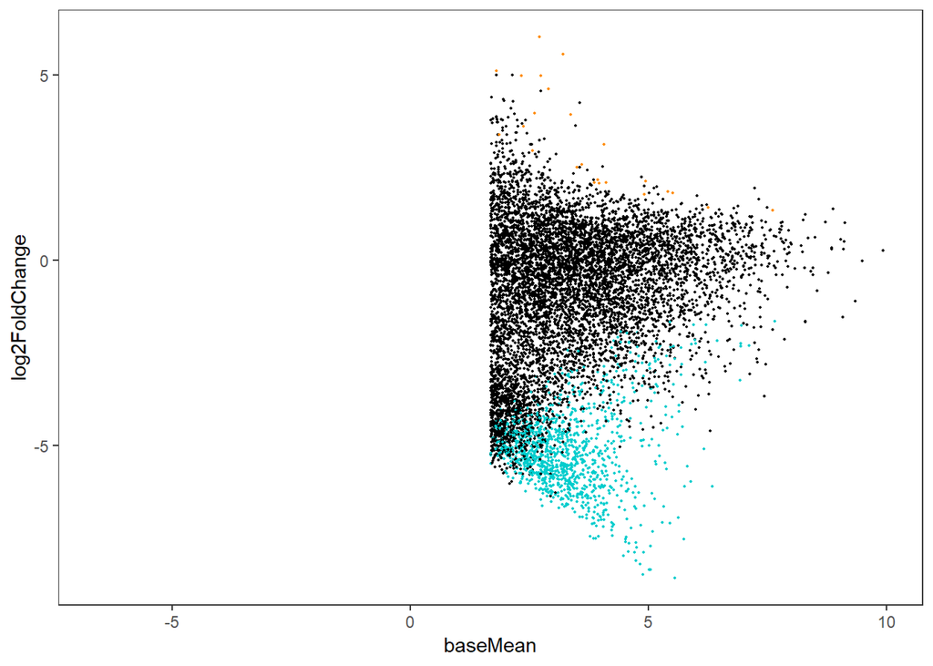

```r
MAttPlot(cd)
```

```r
##########make the GO table for MWU
head(cd)
```

```
##                          baseMean log2FoldChange    lfcSE        stat
## TRINITY_GG_10000_c0_g1 3.82970439      1.6556872 1.431288  1.15678139
## TRINITY_GG_10001_c0_g1 1.45182244     -0.1125841 2.196659 -0.05125244
## TRINITY_GG_10002_c0_g1 4.50386174     -3.0458680 1.775036 -1.71594694
## TRINITY_GG_10003_c0_g1 1.70258343     -4.0525755 2.473250 -1.63856280
## TRINITY_GG_10004_c0_g1 0.48633492     -1.2040537 3.570501 -0.33722263
## TRINITY_GG_10005_c0_g1 0.09315756     -0.2905041 4.521887 -0.06424399
##                            pvalue      padj
## TRINITY_GG_10000_c0_g1 0.24736169 0.5121021
## TRINITY_GG_10001_c0_g1 0.95912436        NA
## TRINITY_GG_10002_c0_g1 0.08617175 0.2660396
## TRINITY_GG_10003_c0_g1 0.10130434        NA
## TRINITY_GG_10004_c0_g1 0.73594908        NA
## TRINITY_GG_10005_c0_g1 0.94877595        NA
```

```r
cd$isogroup=row.names(cd)
library(dplyr)
go_input_DvsC = cd %>%
  mutate(mutated_p = -log(pvalue)) %>%
  mutate(mutated_p_updown = ifelse(log2FoldChange < 0, mutated_p*-1, mutated_p*1)) %>%
  select(isogroup, mutated_p_updown) %>%
  na.omit()

nrow(go_input_DvsC)
```

```
## [1] 22381
```

```r
head(go_input_DvsC)
```

```
##                 isogroup mutated_p_updown
## 1 TRINITY_GG_10000_c0_g1       1.39690370
## 2 TRINITY_GG_10001_c0_g1      -0.04173453
## 3 TRINITY_GG_10002_c0_g1      -2.45141283
## 4 TRINITY_GG_10003_c0_g1      -2.28962598
## 5 TRINITY_GG_10004_c0_g1      -0.30659435
## 6 TRINITY_GG_10005_c0_g1      -0.05258260
```

```r
nrow(go_input_DvsC)
```

```
## [1] 22381
```

```r
colnames(go_input_DvsC) <- c("gene", "pval")
head(go_input_DvsC)
```

```
##                     gene        pval
## 1 TRINITY_GG_10000_c0_g1  1.39690370
## 2 TRINITY_GG_10001_c0_g1 -0.04173453
## 3 TRINITY_GG_10002_c0_g1 -2.45141283
## 4 TRINITY_GG_10003_c0_g1 -2.28962598
## 5 TRINITY_GG_10004_c0_g1 -0.30659435
## 6 TRINITY_GG_10005_c0_g1 -0.05258260
```

```r
write.csv(go_input_DvsC, file="DvsC_GO.csv", quote=F, row.names=FALSE)
```

Based on the resulting number of DEGs for each comparison, it looks like the only comparisons that are of interest for the GO analysis are High Flow + No Heat vs Low Flow + No heat and Low Flow + Heat vs Low Flow + No Heat.

We also generated venn diagrams for these comparisons

To generate venn diagrams we first needed to extract p values and rlog transform them

```r
###############################################################################################
###############################################################################################
###############################################################################################
#--------------get pvals

#A
valAvsB=cbind(resAvsB$pvalue, resAvsB$padj)
head(valAvsB)
```

```
##           [,1]      [,2]
## [1,] 0.7398908 0.9999904
## [2,] 0.5689787 0.9999904
## [3,] 0.9231572 0.9999904
## [4,] 0.7398186 0.9999904
## [5,] 0.8968552 0.9999904
## [6,] 0.8190704 0.9999904
```

```r
colnames(valAvsB)=c("Cond_A", "Cond_B")
length(valAvsB[,1])
```

```
## [1] 22495
```

```r
table(complete.cases(valAvsB))
```

```
##
## FALSE  TRUE
##   114 22381
```

```r
valAvsC=cbind(resAvsC$pvalue, resAvsC$padj)
head(valAvsC)
```

```
##            [,1]      [,2]
## [1,] 0.28330092 0.9987764
## [2,] 0.09172199 0.9987764
## [3,] 0.70601937 0.9987764
## [4,] 0.43581315 0.9987764
## [5,] 0.86263266 0.9987764
## [6,] 0.97160873 0.9987764
```

```r
colnames(valAvsC)=c("Cond_A", "Cond_C")
length(valAvsC[,1])
```

```
## [1] 22495
```

```r
table(complete.cases(valAvsC))
```

```
##
## FALSE  TRUE
##   114 22381
```

```r
valAvsD=cbind(resAvsD$pvalue, resAvsD$padj)
head(valAvsD)
```

```
##            [,1]      [,2]
## [1,] 0.85867840 0.9219040
## [2,] 0.12302793        NA
## [3,] 0.04033195 0.1445138
## [4,] 0.33914702        NA
## [5,] 0.61839818        NA
## [6,] 0.97494621        NA
```

```r
colnames(valAvsD)=c("Cond_A", "Cond_D")
length(valAvsD[,1])
```

```
## [1] 22495
```

```r
table(complete.cases(valAvsD))
```

```
##
## FALSE  TRUE
## 13118  9377
```

```r
#B
valBvsA=cbind(resBvsA$pvalue, resBvsA$padj)
head(valBvsA)
```

```
##           [,1]      [,2]
## [1,] 0.7398908 0.9999904
## [2,] 0.5689787 0.9999904
## [3,] 0.9231572 0.9999904
## [4,] 0.7398186 0.9999904
## [5,] 0.8968552 0.9999904
## [6,] 0.8190704 0.9999904
```

```r
colnames(valBvsA)=c("Cond_B", "Cond_A")
length(valBvsA[,1])
```

```
## [1] 22495
```

```r
table(complete.cases(valBvsA))
```

```
##
## FALSE  TRUE
##   114 22381
```

```r
valBvsC=cbind(resBvsC$pvalue, resBvsC$padj)
head(valBvsC)
```

```
##           [,1]      [,2]
## [1,] 0.1687074 0.9992176
## [2,] 0.0261510 0.9992176
## [3,] 0.6386226 0.9992176
## [4,] 0.6538184 0.9992176
## [5,] 0.7637069 0.9992176
## [6,] 0.8466168 0.9992176
```

```r
colnames(valBvsC)=c("Cond_B", "Cond_C")
length(valBvsC[,1])
```

```
## [1] 22495
```

```r
table(complete.cases(valBvsC))
```

```
##
## FALSE  TRUE
##   114 22381
```

```r
valBvsD=cbind(resBvsD$pvalue, resBvsD$padj)
head(valBvsD)
```

```
##            [,1]      [,2]
## [1,] 0.90121875 0.9439415
## [2,] 0.04426918        NA
## [3,] 0.03388887 0.1081137
## [4,] 0.21183778        NA
## [5,] 0.53944209        NA
## [6,] 0.80860691        NA
```

```r
colnames(valBvsD)=c("Cond_B", "Cond_D")
length(valBvsD[,1])
```

```
## [1] 22495
```

```r
table(complete.cases(valBvsD))
```

```
##
## FALSE  TRUE
## 12685  9810
```

```r
#C
valCvsA=cbind(resCvsA$pvalue, resCvsA$padj)
head(valCvsA)
```

```
##            [,1]      [,2]
## [1,] 0.28330092 0.9987764
## [2,] 0.09172199 0.9987764
## [3,] 0.70601937 0.9987764
## [4,] 0.43581315 0.9987764
## [5,] 0.86263266 0.9987764
## [6,] 0.97160873 0.9987764
```

```r
colnames(valCvsA)=c("Cond_C", "Cond_A")
length(valCvsA[,1])
```

```
## [1] 22495
```

```r
table(complete.cases(valCvsA))
```

```
##
## FALSE  TRUE
##   114 22381
```

```r
valCvsB=cbind(resCvsB$pvalue, resCvsB$padj)
head(valCvsB)
```

```
##           [,1]      [,2]
## [1,] 0.1687074 0.9992176
## [2,] 0.0261510 0.9992176
## [3,] 0.6386226 0.9992176
## [4,] 0.6538184 0.9992176
## [5,] 0.7637069 0.9992176
## [6,] 0.8466168 0.9992176
```

```r
colnames(valCvsB)=c("Cond_C", "Cond_B")
length(valCvsB[,1])
```

```
## [1] 22495
```

```r
table(complete.cases(valCvsB))
```

```
##
## FALSE  TRUE
##   114 22381
```

```r
valCvsD=cbind(resCvsD$pvalue, resCvsD$padj)
head(valCvsD)
```

```
##            [,1]      [,2]
## [1,] 0.24736169 0.5121021
## [2,] 0.95912436        NA
## [3,] 0.08617175 0.2660396
## [4,] 0.10130434        NA
## [5,] 0.73594908        NA
## [6,] 0.94877595        NA
```

```r
colnames(valCvsD)=c("Cond_C", "Cond_D")
length(valCvsD[,1])
```

```
## [1] 22495
```

```r
table(complete.cases(valCvsD))
```

```
##
## FALSE  TRUE
## 14421  8074
```

```r
#D
valDvsA=cbind(resDvsA$pvalue, resDvsA$padj)
head(valDvsA)
```

```
##            [,1]      [,2]
## [1,] 0.85867840 0.9219040
## [2,] 0.12302793        NA
## [3,] 0.04033195 0.1445138
## [4,] 0.33914702        NA
## [5,] 0.61839818        NA
## [6,] 0.97494621        NA
```

```r
colnames(valDvsA)=c("Cond_D", "Cond_A")
length(valDvsA[,1])
```

```
## [1] 22495
```

```r
table(complete.cases(valDvsA))
```

```
##
## FALSE  TRUE
## 13118  9377
```

```r
valDvsB=cbind(resDvsB$pvalue, resDvsB$padj)
head(valDvsB)
```

```
##            [,1]      [,2]
## [1,] 0.90121875 0.9439415
## [2,] 0.04426918        NA
## [3,] 0.03388887 0.1081137
## [4,] 0.21183778        NA
## [5,] 0.53944209        NA
## [6,] 0.80860691        NA
```

```r
colnames(valDvsB)=c("Cond_D", "Cond_B")
length(valDvsB[,1])
```

```
## [1] 22495
```

```r
table(complete.cases(valDvsB))
```

```
##
## FALSE  TRUE
## 12685  9810
```

```r
valDvsC=cbind(resDvsC$pvalue, resDvsC$padj)
head(valDvsC)
```

```
##            [,1]      [,2]
## [1,] 0.24736169 0.5121021
## [2,] 0.95912436        NA
## [3,] 0.08617175 0.2660396
## [4,] 0.10130434        NA
## [5,] 0.73594908        NA
## [6,] 0.94877595        NA
```

```r
colnames(valDvsC)=c("Cond_D", "Cond_C")
length(valDvsC[,1])
```

```
## [1] 22495
```

```r
table(complete.cases(valDvsC))
```

```
##
## FALSE  TRUE
## 14421  8074
```

```r
#################################################################################
#################################################################################
#################################################################################
####### Make rlogdata and pvals table

rlog=rlogTransformation(dds, blind=TRUE)
rld=assay(rlog)
head(rld)
```

```
##                        Cond_A_rep1. Cond_A_rep2. Cond_A_rep3. Cond_A_rep4.
## TRINITY_GG_10000_c0_g1    0.5311886    1.8010369    1.8915304    2.4391701
## TRINITY_GG_10001_c0_g1    0.5502531    0.3916297   -0.1922238    0.8550256
## TRINITY_GG_10002_c0_g1    1.8461955    1.8300137    1.3884830    2.6446686
## TRINITY_GG_10003_c0_g1   -0.5901948   -0.1880202   -0.3375680    0.8073518
## TRINITY_GG_10004_c0_g1   -1.0993208   -0.5639490   -0.9285210   -0.6365088
## TRINITY_GG_10005_c0_g1   -1.7750965   -1.8197431   -1.7270495   -1.7343781
##                        Cond_B_rep1. Cond_B_rep2. Cond_B_rep3. Cond_B_rep4.
## TRINITY_GG_10000_c0_g1    2.3759087    1.9645011    1.2672070    2.3599464
## TRINITY_GG_10001_c0_g1    0.9476190    1.1034799    0.7957348    0.6606056
## TRINITY_GG_10002_c0_g1    2.8072197    1.9313338    1.6207548    1.4720493
## TRINITY_GG_10003_c0_g1    0.9519777   -0.4702615    0.2689057    0.1566861
## TRINITY_GG_10004_c0_g1   -0.8332738   -1.0038348   -0.1247506   -1.0559625
## TRINITY_GG_10005_c0_g1   -1.6005192   -1.7482357   -1.7485727   -1.7628995
##                        Cond_C_rep1. Cond_C_rep2. Cond_C_rep3. Cond_C_rep4.
## TRINITY_GG_10000_c0_g1    0.9967916    1.7135964    0.7601960   0.84060675
## TRINITY_GG_10001_c0_g1   -0.4130902   -0.5810097   -0.1497704  -0.04372675
## TRINITY_GG_10002_c0_g1    0.3678972    1.1094614    0.6572072   2.99203513
## TRINITY_GG_10003_c0_g1    0.3913886   -0.8325694    1.8944164  -0.18125720
## TRINITY_GG_10004_c0_g1   -0.6991001   -1.1959048   -0.9031576  -0.83980258
## TRINITY_GG_10005_c0_g1   -1.7834837   -1.8207189   -1.7199146  -1.70209251
##                        Cond_D_rep1. Cond_D_rep3. Cond_D_rep4.
## TRINITY_GG_10000_c0_g1    2.0335953   0.93304931    2.4190236
## TRINITY_GG_10001_c0_g1   -0.5008472   0.04322797   -0.4468168
## TRINITY_GG_10002_c0_g1    0.1989960   1.75801184    0.3043565
## TRINITY_GG_10003_c0_g1   -0.7235488  -0.08972699   -0.6546837
## TRINITY_GG_10004_c0_g1   -1.1719849  -0.78785215   -1.1541435
## TRINITY_GG_10005_c0_g1   -1.8188801  -1.68747855   -1.7995190
```

```r
colnames(rld)=paste(colData$treat)
head(rld)
```

```
##                            Cond_A     Cond_A     Cond_A     Cond_A
## TRINITY_GG_10000_c0_g1  0.5311886  1.8010369  1.8915304  2.4391701
## TRINITY_GG_10001_c0_g1  0.5502531  0.3916297 -0.1922238  0.8550256
## TRINITY_GG_10002_c0_g1  1.8461955  1.8300137  1.3884830  2.6446686
## TRINITY_GG_10003_c0_g1 -0.5901948 -0.1880202 -0.3375680  0.8073518
## TRINITY_GG_10004_c0_g1 -1.0993208 -0.5639490 -0.9285210 -0.6365088
## TRINITY_GG_10005_c0_g1 -1.7750965 -1.8197431 -1.7270495 -1.7343781
##                            Cond_B     Cond_B     Cond_B     Cond_B
## TRINITY_GG_10000_c0_g1  2.3759087  1.9645011  1.2672070  2.3599464
## TRINITY_GG_10001_c0_g1  0.9476190  1.1034799  0.7957348  0.6606056
## TRINITY_GG_10002_c0_g1  2.8072197  1.9313338  1.6207548  1.4720493
## TRINITY_GG_10003_c0_g1  0.9519777 -0.4702615  0.2689057  0.1566861
## TRINITY_GG_10004_c0_g1 -0.8332738 -1.0038348 -0.1247506 -1.0559625
## TRINITY_GG_10005_c0_g1 -1.6005192 -1.7482357 -1.7485727 -1.7628995
##                            Cond_C     Cond_C     Cond_C      Cond_C
## TRINITY_GG_10000_c0_g1  0.9967916  1.7135964  0.7601960  0.84060675
## TRINITY_GG_10001_c0_g1 -0.4130902 -0.5810097 -0.1497704 -0.04372675
## TRINITY_GG_10002_c0_g1  0.3678972  1.1094614  0.6572072  2.99203513
## TRINITY_GG_10003_c0_g1  0.3913886 -0.8325694  1.8944164 -0.18125720
## TRINITY_GG_10004_c0_g1 -0.6991001 -1.1959048 -0.9031576 -0.83980258
## TRINITY_GG_10005_c0_g1 -1.7834837 -1.8207189 -1.7199146 -1.70209251
##                            Cond_D      Cond_D     Cond_D
## TRINITY_GG_10000_c0_g1  2.0335953  0.93304931  2.4190236
## TRINITY_GG_10001_c0_g1 -0.5008472  0.04322797 -0.4468168
## TRINITY_GG_10002_c0_g1  0.1989960  1.75801184  0.3043565
## TRINITY_GG_10003_c0_g1 -0.7235488 -0.08972699 -0.6546837
## TRINITY_GG_10004_c0_g1 -1.1719849 -0.78785215 -1.1541435
## TRINITY_GG_10005_c0_g1 -1.8188801 -1.68747855 -1.7995190
```

```r
length(rld[,1])
```

```
## [1] 22495
```

```r
rldpvals=cbind(rld,valAvsB, valAvsC, valAvsD, valBvsA, valBvsC, valBvsD,valCvsA,valCvsB,valCvsD,valDvsA,valDvsB,valDvsC)

dim(rldpvals)
```

```
## [1] 22495    39
```

```r
#
table(complete.cases(rldpvals))
```

```
##
## FALSE  TRUE
## 14421  8074
```

```r
# FALSE  TRUE
#

write.csv(rldpvals, "Total_Sym_Pvals.csv", quote=F)

head(matrix(rld))
```

```
##            [,1]
## [1,]  0.5311886
## [2,]  0.5502531
## [3,]  1.8461955
## [4,] -0.5901948
## [5,] -1.0993208
## [6,] -1.7750965
```

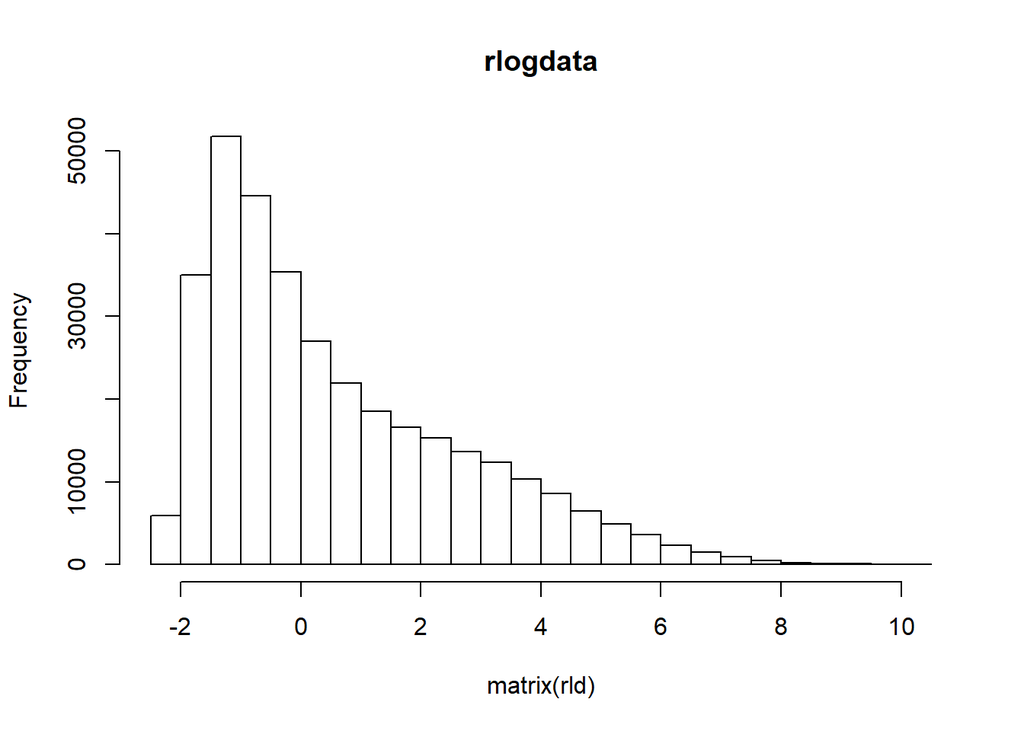

```r
hist(matrix(rld), main="rlogdata")
```

```r
colnames(rld)=paste(colData$treat)
head(rld)
```

```
##                            Cond_A     Cond_A     Cond_A     Cond_A
## TRINITY_GG_10000_c0_g1  0.5311886  1.8010369  1.8915304  2.4391701
## TRINITY_GG_10001_c0_g1  0.5502531  0.3916297 -0.1922238  0.8550256
## TRINITY_GG_10002_c0_g1  1.8461955  1.8300137  1.3884830  2.6446686
## TRINITY_GG_10003_c0_g1 -0.5901948 -0.1880202 -0.3375680  0.8073518
## TRINITY_GG_10004_c0_g1 -1.0993208 -0.5639490 -0.9285210 -0.6365088
## TRINITY_GG_10005_c0_g1 -1.7750965 -1.8197431 -1.7270495 -1.7343781
##                            Cond_B     Cond_B     Cond_B     Cond_B
## TRINITY_GG_10000_c0_g1  2.3759087  1.9645011  1.2672070  2.3599464
## TRINITY_GG_10001_c0_g1  0.9476190  1.1034799  0.7957348  0.6606056
## TRINITY_GG_10002_c0_g1  2.8072197  1.9313338  1.6207548  1.4720493
## TRINITY_GG_10003_c0_g1  0.9519777 -0.4702615  0.2689057  0.1566861
## TRINITY_GG_10004_c0_g1 -0.8332738 -1.0038348 -0.1247506 -1.0559625
## TRINITY_GG_10005_c0_g1 -1.6005192 -1.7482357 -1.7485727 -1.7628995
##                            Cond_C     Cond_C     Cond_C      Cond_C
## TRINITY_GG_10000_c0_g1  0.9967916  1.7135964  0.7601960  0.84060675
## TRINITY_GG_10001_c0_g1 -0.4130902 -0.5810097 -0.1497704 -0.04372675
## TRINITY_GG_10002_c0_g1  0.3678972  1.1094614  0.6572072  2.99203513
## TRINITY_GG_10003_c0_g1  0.3913886 -0.8325694  1.8944164 -0.18125720
## TRINITY_GG_10004_c0_g1 -0.6991001 -1.1959048 -0.9031576 -0.83980258
## TRINITY_GG_10005_c0_g1 -1.7834837 -1.8207189 -1.7199146 -1.70209251
##                            Cond_D      Cond_D     Cond_D
## TRINITY_GG_10000_c0_g1  2.0335953  0.93304931  2.4190236
## TRINITY_GG_10001_c0_g1 -0.5008472  0.04322797 -0.4468168
## TRINITY_GG_10002_c0_g1  0.1989960  1.75801184  0.3043565
## TRINITY_GG_10003_c0_g1 -0.7235488 -0.08972699 -0.6546837
## TRINITY_GG_10004_c0_g1 -1.1719849 -0.78785215 -1.1541435
## TRINITY_GG_10005_c0_g1 -1.8188801 -1.68747855 -1.7995190
```

```r
# VENN Diagrams

##########
# First summarize all up/down regulated
#A
A1_up=row.names(resAvsB[resAvsB$padj<0.1 & !is.na(resAvsB$padj) & resAvsB$log2FoldChange>0,])
length(A1_up) #0
```

```
## [1] 0
```

```r
A1_down=row.names(resAvsB[resAvsB$padj<0.1 & !is.na(resAvsB$padj) & resAvsB$log2FoldChange<0,])
length(A1_down) #0
```

```
## [1] 0
```

```r
A2_up=row.names(resAvsC[resAvsC$padj<0.1 & !is.na(resAvsC$padj) & resAvsC$log2FoldChange>0,])
length(A2_up) #1
```

```
## [1] 1
```

```r
A2_down=row.names(resAvsC[resAvsC$padj<0.1 & !is.na(resAvsC$padj) & resAvsC$log2FoldChange<0,])
length(A2_down) #0
```

```
## [1] 0
```

```r
A3_up=row.names(resAvsD[resAvsD$padj<0.1 & !is.na(resAvsD$padj) & resAvsD$log2FoldChange>0,])
length(A3_up) #
```

```
## [1] 1691
```

```r
A3_down=row.names(resAvsD[resAvsD$padj<0.1 & !is.na(resAvsD$padj) & resAvsD$log2FoldChange<0,])
length(A3_down) #
```

```
## [1] 133
```

```r
#All A
A1=row.names(resAvsB[resAvsB$padj<0.1 & !is.na(resAvsB$padj),])
A2=row.names(resBvsC[resBvsC$padj<0.1 & !is.na(resBvsC$padj),])
A3=row.names(resBvsD[resBvsD$padj<0.1 & !is.na(resBvsD$padj),])
#Up for A
A12_up=union(A1_up,A2_up)
A_up=union(A12_up,A3_up)
length(A_up)
```

```
## [1] 1691
```

```r
#
#Down for A
A12_down=union(A1_down,A2_down)
A_down=union(A12_down,A3_down)
length(A_down)
```

```
## [1] 133
```

```r
#
#All for A
A12=union(A1,A2)
A=union(A12,A3)
length(A)
```

```
## [1] 2851
```

```r
#

#B
B1_up=row.names(resBvsA[resBvsA$padj<0.1 & !is.na(resBvsA$padj) & resBvsA$log2FoldChange>0,])
length(B1_up) #
```

```
## [1] 0
```

```r
B1_down=row.names(resBvsA[resBvsA$padj<0.1 & !is.na(resBvsA$padj) & resBvsA$log2FoldChange<0,])
length(B1_down) #
```

```
## [1] 0
```

```r
B2_up=row.names(resBvsC[resBvsC$padj<0.1 & !is.na(resBvsC$padj) & resBvsC$log2FoldChange>0,])
length(B2_up) #
```

```
## [1] 1
```

```r
B2_down=row.names(resBvsC[resBvsC$padj<0.1 & !is.na(resBvsC$padj) & resBvsC$log2FoldChange<0,])
length(B2_down) #
```

```
## [1] 0
```

```r
B3_up=row.names(resBvsD[resBvsD$padj<0.1 & !is.na(resBvsD$padj) & resBvsD$log2FoldChange>0,])
length(B3_up) #
```

```
## [1] 2597
```

```r
B3_down=row.names(resBvsD[resBvsD$padj<0.1 & !is.na(resBvsD$padj) & resBvsD$log2FoldChange<0,])
length(B3_down) #
```

```
## [1] 254
```

```r
#All B
B1=row.names(resBvsA[resBvsA$padj<0.1 & !is.na(resBvsA$padj),])
B2=row.names(resBvsC[resBvsC$padj<0.1 & !is.na(resBvsC$padj),])
B3=row.names(resBvsD[resBvsD$padj<0.1 & !is.na(resBvsD$padj),])
#Up for B
B12_up=union(B1_up,B2_up)
B_up=union(B12_up,B3_up)
length(B_up)
```

```
## [1] 2597
```

```r
#
#Down for B
B12_down=union(B1_down,B2_down)
B_down=union(B12_down,B3_down)
length(B_down)
```

```
## [1] 254
```

```r
#
#All for B
B12=union(B1,B2)
B=union(B12,B3)
length(B)
```

```
## [1] 2851
```

```r
#

#C
C1_up=row.names(resCvsA[resCvsA$padj<0.1 & !is.na(resCvsA$padj) & resCvsA$log2FoldChange>0,])
length(C1_up) #
```

```
## [1] 0
```

```r
C1_down=row.names(resCvsA[resCvsA$padj<0.1 & !is.na(resCvsA$padj) & resCvsA$log2FoldChange<0,])
length(C1_down) #
```

```
## [1] 1
```

```r
C2_up=row.names(resCvsB[resCvsB$padj<0.1 & !is.na(resCvsB$padj) & resCvsB$log2FoldChange>0,])
length(C2_up) #
```

```
## [1] 0
```

```r
C2_down=row.names(resCvsB[resCvsB$padj<0.1 & !is.na(resCvsB$padj) & resCvsB$log2FoldChange<0,])
length(C2_down) #
```

```
## [1] 1
```

```r
C3_up=row.names(resCvsD[resCvsD$padj<0.1 & !is.na(resCvsD$padj) & resCvsD$log2FoldChange>0,])
length(C3_up) #
```

```
## [1] 1160
```

```r
C3_down=row.names(resCvsD[resCvsD$padj<0.1 & !is.na(resCvsD$padj) & resCvsD$log2FoldChange<0,])
length(C3_down) #
```

```
## [1] 24
```

```r
#All C
C1=row.names(resCvsA[resCvsA$padj<0.1 & !is.na(resCvsA$padj),])
C2=row.names(resBvsC[resBvsC$padj<0.1 & !is.na(resBvsC$padj),])
C3=row.names(resCvsD[resCvsD$padj<0.1 & !is.na(resCvsD$padj),])
#Up for C
C12_up=union(C1_up,C2_up)
C_up=union(C12_up,C3_up)
length(C_up)
```

```
## [1] 1160
```

```r
#
#Down for C
C12_down=union(C1_down,C2_down)
length(C12_down)
```

```
## [1] 1
```

```r
C_down=union(C12_down,C3_down)
length(C_down)
```

```
## [1] 25
```

```r
#
#All for C
C12=union(C1,C2)
length(C12)
```

```
## [1] 1
```

```r
C=union(C12,C3)
length(C)
```

```
## [1] 1185
```

```r
#

#D
D1_up=row.names(resDvsA[resDvsA$padj<0.1 & !is.na(resDvsA$padj) & resDvsA$log2FoldChange>0,])
length(D1_up) #
```

```
## [1] 133
```

```r
D1_down=row.names(resDvsA[resDvsA$padj<0.1 & !is.na(resDvsA$padj) & resDvsA$log2FoldChange<0,])
length(D1_down) #
```

```
## [1] 1691
```

```r
D2_up=row.names(resDvsB[resDvsB$padj<0.1 & !is.na(resDvsB$padj) & resDvsB$log2FoldChange>0,])
length(D2_up) #
```

```
## [1] 254
```

```r
D2_down=row.names(resDvsB[resDvsB$padj<0.1 & !is.na(resDvsB$padj) & resDvsB$log2FoldChange<0,])
length(D2_down) #
```

```
## [1] 2597
```

```r
D3_up=row.names(resDvsC[resDvsC$padj<0.1 & !is.na(resDvsC$padj) & resDvsC$log2FoldChange>0,])
length(D3_up) #
```

```
## [1] 24
```

```r
D3_down=row.names(resDvsC[resDvsC$padj<0.1 & !is.na(resDvsC$padj) & resDvsC$log2FoldChange<0,])
length(D3_down) #
```

```
## [1] 1160
```

```r
#All D
D1=row.names(resDvsA[resDvsA$padj<0.1 & !is.na(resDvsA$padj),])
D2=row.names(resDvsB[resDvsB$padj<0.1 & !is.na(resDvsB$padj),])
D3=row.names(resDvsC[resDvsC$padj<0.1 & !is.na(resDvsC$padj),])
#Up for D
D12_up=union(D1_up,D2_up)
length(D12_up)
```

```
## [1] 279
```

```r
D_up=union(D12_up,D3_up)
length(D_up)
```

```
## [1] 295
```

```r
#
#Down for D
D12_down=union(D1_down,D2_down)
D_down=union(D12_down,D3_down)
length(D_down)
```

```
## [1] 2764
```

```r
#
#All for D
D12=union(D1,D2)
D=union(D12,D3)
length(D)
```

```
## [1] 3059
```

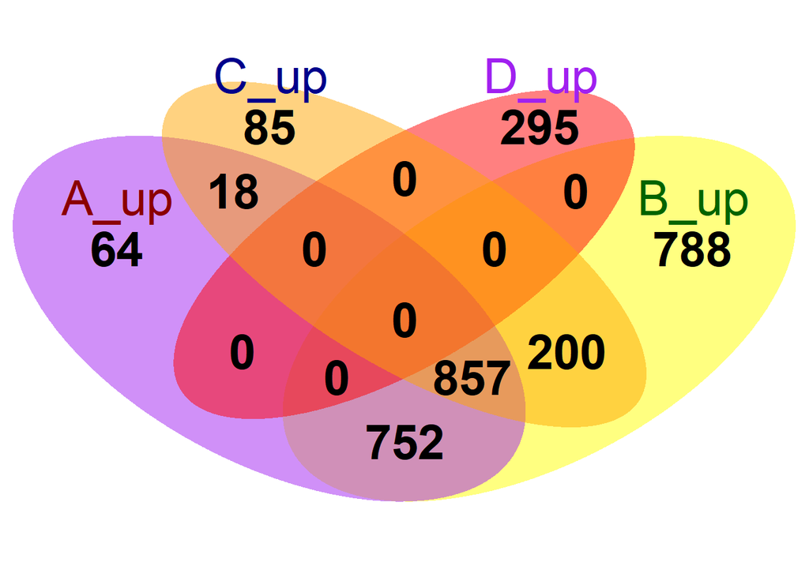

```r
#

##################
##################
#Now we can compare

#All up
candidates=list("A_up"=A_up, "B_up"=B_up, "C_up"=C_up,"D_up"=D_up)
grid.newpage() #makes a new plotting space for the Venn Diagram to fit
prettyvenn=venn.diagram(
  x = candidates,
  filename=NULL,
  col = "transparent",
  fill = c("purple", "yellow","orange","red"),
  alpha = 0.5,
  # label.col = c("darkred", "white", "darkgreen", "white", "white", "white", "blue4"),
  cex = 2.5,
  fontfamily = "sans",
  fontface = "bold",
  cat.default.pos = "text",
  cat.col = c("darkred", "darkgreen","darkblue", "purple"),
  cat.cex = 2.5,
  cat.fontfamily = "sans",
  cat.dist = c(0.08, 0.08, 0.08, 0.08),
  cat.pos = 1
);
grid.draw(prettyvenn)
```

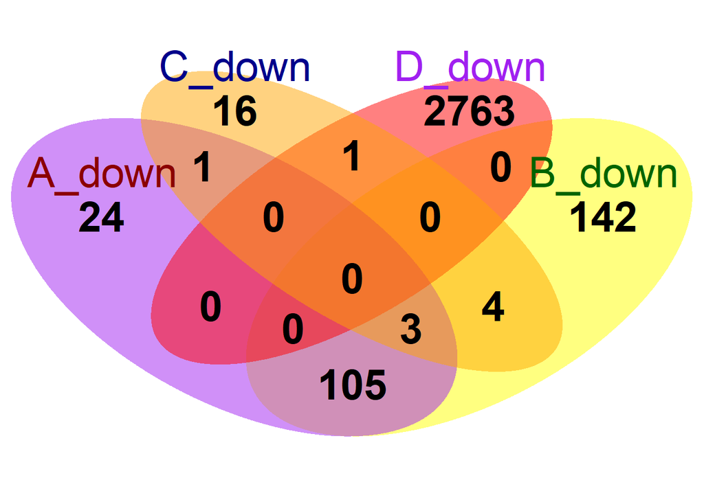

```r
#All down
candidates=list("A_down"=A_down, "B_down"=B_down, "C_down"=C_down,"D_down"=D_down)
grid.newpage() #makes a new plotting space for the Venn Diagram to fit
prettyvenn=venn.diagram(
  x = candidates,
  filename=NULL,
  col = "transparent",
  fill = c("purple", "yellow","orange","red"),
  alpha = 0.5,
  # label.col = c("darkred", "white", "darkgreen", "white", "white", "white", "blue4"),
  cex = 2.5,
  fontfamily = "sans",
  fontface = "bold",
  cat.default.pos = "text",
  cat.col = c("darkred", "darkgreen","darkblue", "purple"),
  cat.cex = 2.5,
  cat.fontfamily = "sans",
  cat.dist = c(0.08, 0.08, 0.08, 0.08),
  cat.pos = 1
);
grid.draw(prettyvenn)
```

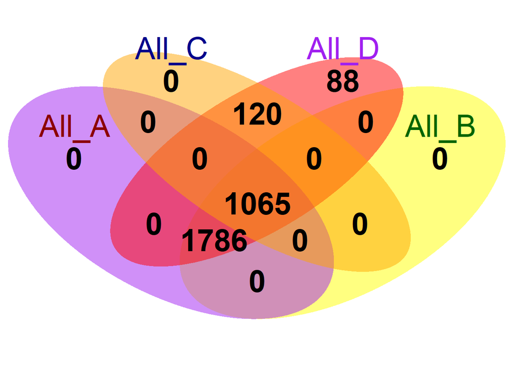

```r
#All
candidates=list("All_A"=A, "All_B"=B, "All_C"=C,"All_D"=D)
grid.newpage() #makes a new plotting space for the Venn Diagram to fit
prettyvenn=venn.diagram(
  x = candidates,
  filename=NULL,
  col = "transparent",
  fill = c("purple", "yellow","orange","red"),
  alpha = 0.5,
  # label.col = c("darkred", "white", "darkgreen", "white", "white", "white", "blue4"),
  cex = 2.5,
  fontfamily = "sans",
  fontface = "bold",
  cat.default.pos = "text",
  cat.col = c("darkred", "darkgreen","darkblue", "purple"),
  cat.cex = 2.5,
  cat.fontfamily = "sans",
  cat.dist = c(0.08, 0.08, 0.08, 0.08),
  cat.pos = 1
);
grid.draw(prettyvenn)
```

Because there was no “control” in the experiment, our Venn Diagrams are a little unhelpful. However, it looks like condition D (Low Flow + No Heat) could be showing a different expression pattern from the rest. We create a heatmap to explore this further

```r
rldpvals <- read.csv(file="Total_Sym_Pvals.csv", row.names=1)

rld=rldpvals[,1:15]
#head(rld)

sampleDists <- dist(t(rld))
sampleDistMatrix <- as.matrix(sampleDists)
treat==c( "Cond_A", "Cond_A", "Cond_A" , "Cond_A", "Cond_B","Cond_B", "Cond_B", "Cond_B", "Cond_C","Cond_C","Cond_C","Cond_C","Cond_D","Cond_D","Cond_D")
```

```
##  [1] TRUE TRUE TRUE TRUE TRUE TRUE TRUE TRUE TRUE TRUE TRUE TRUE TRUE TRUE
## [15] TRUE
```

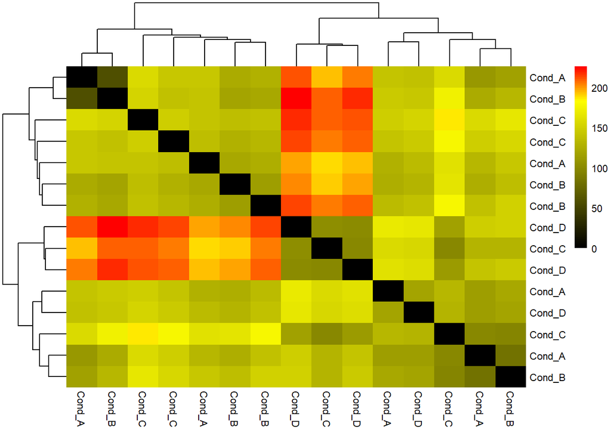

```r
colnames(sampleDistMatrix)=paste(treat)
rownames(sampleDistMatrix)=paste(treat)
#Set colors and parameters
heat.colors = colorRampPalette(rev(c("red","yellow","black")),bias=0.3)(100)
pheatmap(sampleDistMatrix,color = heat.colors,cex=0.9,border_color=NA,cluster_rows=T,cluster_cols=T)
```

There looks to be little clustering according to treatment except for D (Low Flow + No Heat)

We explored further with a PCA and a PCoA (this was only run to look for variance explained by treatment, not genotype).

```r
##########################################################
#Principle Component Analysis
rld_t=t(rld)
which(apply(rld_t, 2, var)==0) #identify which columns have zero variance, PCA will not work on these
```

[output not shown]

```r
rld_t = rld_t[ , apply(rld_t, 2, var) != 0] #removes columns with zero variance
pca <- prcomp(rld_t,center = TRUE, scale. = TRUE, na.action = na.omit) #Scale = TRUE is advisable
```

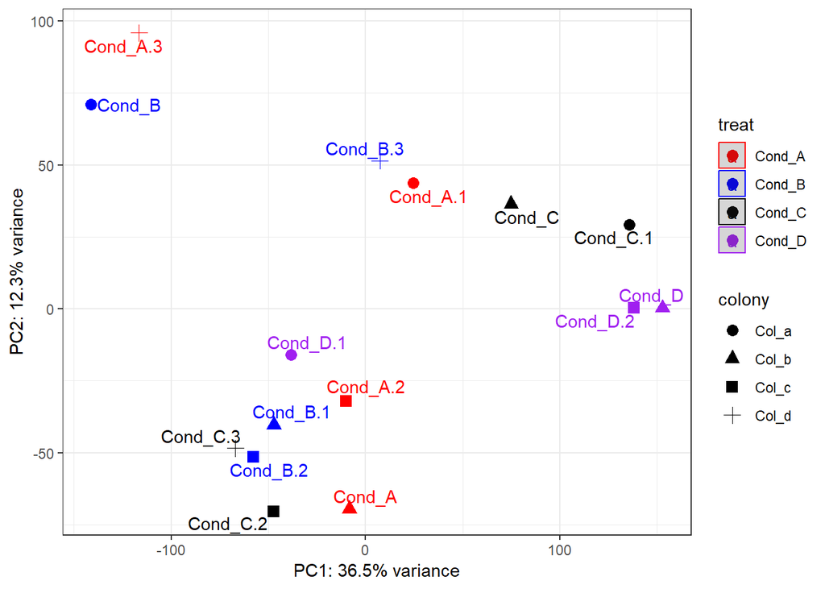

```r
#head(pca)
#Introduce principle components
li <- pca$sdev^2 / sum(pca$sdev^2)
pc1v <- round(li[1] * 100, 1)
pc2v <- round(li[2] * 100, 1)
pca_s <- as.data.frame(pca$x)
#head(pca_s)
pca_s <- pca_s[,c(1,2)]
pca_s$Samples = row.names(pca_s)
pca_s$treat=colData$treat
pca_s$colony=colData$colony
#head(pca_s)
#Set parameters and components
cbPalette <- c("red", "blue", "black", "purple")
ggplot(pca_s, aes(PC1, PC2, color = treat, pch = colony)) +
  geom_point(size=3) +
  geom_text_repel(aes(label=Samples)) +
  scale_colour_manual(values=cbPalette)+
  theme_bw() +
  # geom_density2d(alpha=.5)+
  geom_polygon(alpha=.2)+
  xlab(paste0("PC1: ",pc1v,"% variance")) +
  ylab(paste0("PC2: ",pc2v,"% variance"))
```

```r
#Run adonis for significance
adonis(pca$x ~ treat, data = pca_s, method='eu', na.rm = TRUE)
```

```
##
## Call:
## adonis(formula = pca$x ~ treat, data = pca_s, method = "eu",      na.rm = TRUE)
##
## Permutation: free
## Number of permutations: 999
##
## Terms added sequentially (first to last)
##
##           Df SumsOfSqs MeanSqs F.Model      R2 Pr(>F)
## treat      3     78993   26331  1.2327 0.25161  0.196
## Residuals 11    234957   21360         0.74839
## Total     14    313950                 1.00000
```

```r
#No prinicple is significant

#######################################################################
######################################################################
# Principle coordiante analysis

#Redo the file formating of files

#read in counts
counts = read.table("SymCounts.csv")
# how many genes we have total?
nrow(counts) #22495
```

```
## [1] 22495
```

```r
# how the data look?
#head(counts)
# how many genes have mean count >=3?
means=apply(counts,1,mean)
table(means>=3)
```

```
##
## FALSE  TRUE
## 11272 11223
```

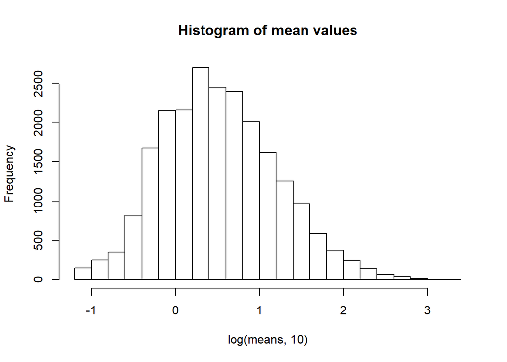

```r
#FALSE  TRUE


hist(log(means,10), main="Histogram of mean values")
```

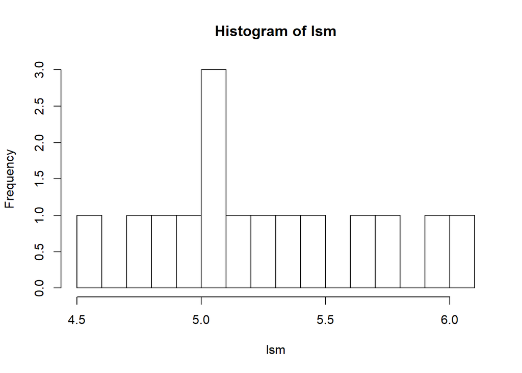

```r
# distribution of total counts among samples: are there samples with less than 2SD counts?
smeans=apply(counts,2,sum)
lsm=log(smeans,10)
hist(lsm,breaks=12)
```

```r
sdl=sd(lsm)
bads=which(mean(lsm)-lsm > 2*sdl)
bads
```

```
## named integer(0)
```

```r
# removing all genes with mean count less than 3
countData=counts[means>=3, ]
nrow(countData) #11223
```

```
## [1] 11223
```

```r
m <- as.matrix(countData)
storage.mode(m) = "integer"
head(m)
```

```
##                        Cond_A_rep1. Cond_A_rep2. Cond_A_rep3. Cond_A_rep4.
## TRINITY_GG_10000_c0_g1            0           12            2           23
## TRINITY_GG_10002_c0_g1            4           13            1           29
## TRINITY_GG_10006_c0_g1            6           10            0           16
## TRINITY_GG_10007_c0_g1           14           13            0           40
## TRINITY_GG_10009_c0_g1           13           29            0           24
## TRINITY_GG_10011_c0_g1           18            1            3           18
##                        Cond_B_rep1. Cond_B_rep2. Cond_B_rep3. Cond_B_rep4.
## TRINITY_GG_10000_c0_g1           38            3            1            6
## TRINITY_GG_10002_c0_g1           61            3            2            2
## TRINITY_GG_10006_c0_g1           49            3            1            1
## TRINITY_GG_10007_c0_g1           86            1           16            7
## TRINITY_GG_10009_c0_g1           70            2            5            6
## TRINITY_GG_10011_c0_g1           32            1            9            1
##                        Cond_C_rep1. Cond_C_rep2. Cond_C_rep3. Cond_C_rep4.
## TRINITY_GG_10000_c0_g1            1           22            0            0
## TRINITY_GG_10002_c0_g1            0           10            0            5
## TRINITY_GG_10006_c0_g1            0            0            5            0
## TRINITY_GG_10007_c0_g1            3           41            3            2
## TRINITY_GG_10009_c0_g1            4            0            0            0
## TRINITY_GG_10011_c0_g1            0            0            5            7
##                        Cond_D_rep1. Cond_D_rep3. Cond_D_rep4.
## TRINITY_GG_10000_c0_g1           11            0           11
## TRINITY_GG_10002_c0_g1            0            1            0
## TRINITY_GG_10006_c0_g1            0            0            0
## TRINITY_GG_10007_c0_g1            0            0            5
## TRINITY_GG_10009_c0_g1            0            1            0
## TRINITY_GG_10011_c0_g1            0            0            0
```

```r
treat=c( "Cond_A", "Cond_A", "Cond_A" , "Cond_A", "Cond_B","Cond_B", "Cond_B", "Cond_B", "Cond_C","Cond_C","Cond_C","Cond_C","Cond_D","Cond_D","Cond_D")
colony=as.factor (c( "Col_b", "Col_a", "Col_c", "Col_d", "Col_a","Col_b", "Col_c", "Col_d", "Col_b","Col_a","Col_c","Col_d","Col_b","Col_a","Col_c"))
g=data.frame(treat, colony)
#g=data.frame(treat)
g
```

```
##     treat colony
## 1  Cond_A  Col_b
## 2  Cond_A  Col_a
## 3  Cond_A  Col_c
## 4  Cond_A  Col_d
## 5  Cond_B  Col_a
## 6  Cond_B  Col_b
## 7  Cond_B  Col_c
## 8  Cond_B  Col_d
## 9  Cond_C  Col_b
## 10 Cond_C  Col_a
## 11 Cond_C  Col_c
## 12 Cond_C  Col_d
## 13 Cond_D  Col_b
## 14 Cond_D  Col_a
## 15 Cond_D  Col_c
```

```r
colData<- g

# make big dataframe
dds<-DESeq2::DESeqDataSetFromMatrix(countData=m, colData=colData, design=~treat+colony)
dds<-DESeq(dds)
```

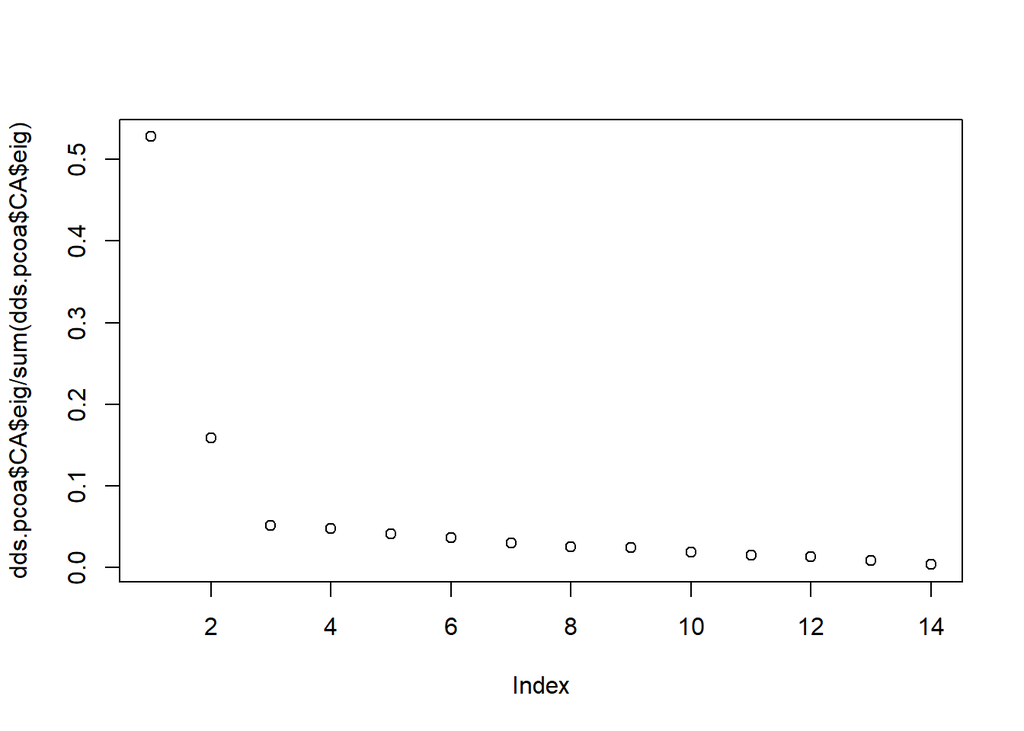

```r
#Vsd=varianceStabilizingTransformation(dds)
rl=rlog(dds)
e=ExpressionSet(assay(rl), AnnotatedDataFrame(as.data.frame(colData(rl))))
save(dds,colData,m,rl,file="initial.RData")
# generating normalized variance-stabilized data for PCoA and heatmaps
load("initial.RData")
vsd=assay(rl)
snames=paste(colnames(m),g,sep=".")
colnames(vsd)=snames
save(vsd,g,file="vsd.RData")
# heatmap and hierarchical clustering:
load("vsd.RData")


# Principle coordiante analysis
conditions=g
g=paste(treat,colony,sep=".")
#colors and subsetters:
indcols=rep("black",ncol(vsd))
indcols[g=="Cond_A"]="purple"
indcols[g=="Cond_B"]="red"
indcols[g=="Cond_C"]="green2"
indcols[g=="Cond_D"]="blue"
dds.pcoa=capscale(dist(t(vsd),method="manhattan")~1)

# how many good PC's we have?
plot(dds.pcoa$CA$eig/sum(dds.pcoa$CA$eig))
```

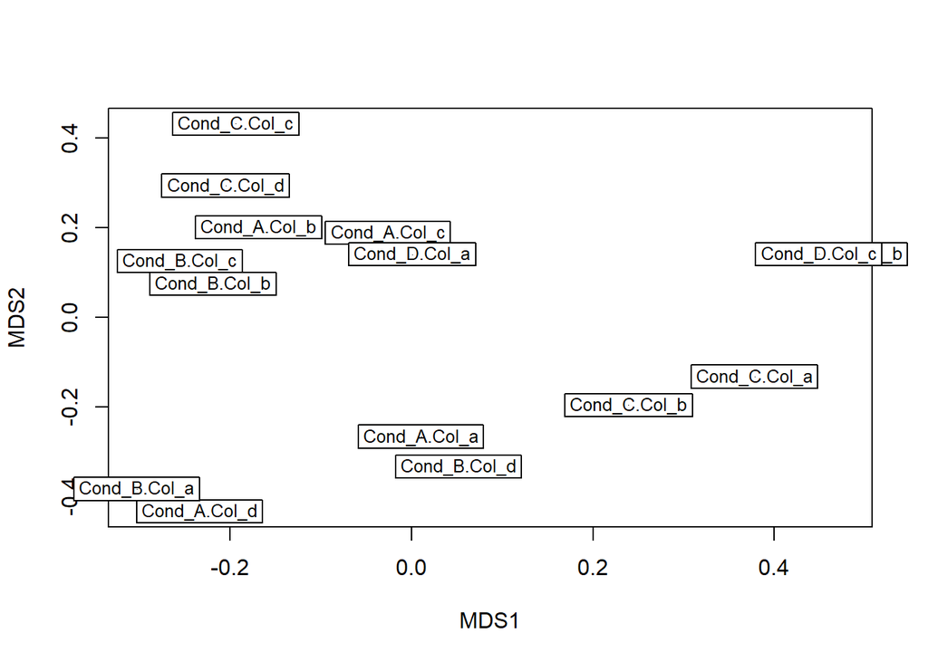

```r
scores=dds.pcoa$CA$u

# plotting PCoA
axes2plot=c(1,2)
plot(scores[,axes2plot],col=indcols,pch=15)
ordispider(scores,g,label=T,col="grey")
#ordiellipse(scores,conditions$trt,label=T,draw="polygon",col="grey90",cex=2)
ordihull(scores,g,draw="polygon",col="grey",cex=2)
```

[figure not shown]

```r
# neighbor-joining tree of samples (based on significant PCo's):
tre=nj(dist(scores[,1:4]))
plot(tre,cex=0.8,type="unrooted")
```

We also created the PCoA in ggplot to make it prettier.

```r
#####PCoA in ggplot r########
a.con=data.frame(cbind(colony,treat))
a.con
```

```
##    colony  treat
## 1       2 Cond_A
## 2       1 Cond_A
## 3       3 Cond_A
## 4       4 Cond_A
## 5       1 Cond_B
## 6       2 Cond_B
## 7       3 Cond_B
## 8       4 Cond_B
## 9       2 Cond_C
## 10      1 Cond_C
## 11      3 Cond_C
## 12      4 Cond_C
## 13      2 Cond_D
## 14      1 Cond_D
## 15      3 Cond_D
```

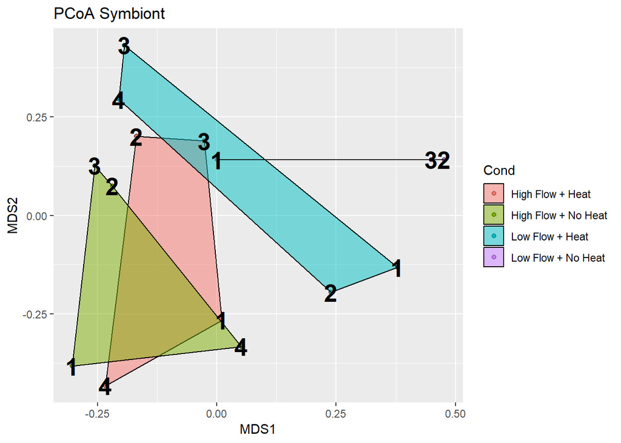

```r
vsd=assay(rl)
snames=paste(colnames(countData),a.con[,2],sep=".")
colnames(vsd)=snames
save(vsd,a.con,file="vsd.RData")
load("vsd.RData")
conditions=a.con
conditions$ibyt=paste(conditions[,1],conditions[,2],sep=".")
dds.pcoa=capscale(dist(t(vsd),method="manhattan")~1)
scores=dds.pcoa$CA$u

data.scores <- as.data.frame(scores)  #Using the scores function from vegan to extract the site scores and convert to a data.frame
data.scores$sample <- rownames(data.scores)  # create a column of sample names, from the rownames of data.scores
data.scores$grp <- a.con$treat #  add group variable
data.scores$colony <- a.con$colony
library(dplyr)
hull_cyl <- data.scores %>%
  group_by(grp) %>%
  dplyr::slice(chull(MDS1, MDS2))

p <- ggplot(data.scores, aes(MDS1, MDS2)) + geom_point(shape = 21)
p + aes(fill = factor(grp)) + geom_polygon(data = hull_cyl, alpha = 0.5, color='black')+
  geom_text(data=data.scores,
            aes(MDS1, MDS2 , label = colony),
            color= "black", size=7, fontface = 2,
            hjust = 0.5, vjust = 0.5)+
scale_fill_discrete(name = "Cond", labels = c("High Flow + Heat", "High Flow + No Heat", "Low Flow + Heat","Low Flow + No Heat"))+
  labs(title="PCoA Symbiont")
```

The PCA and PCoA found the variance wasn’t significantly explained by treatment group. However the clustering still shows some interesting things. It appears there is clustering according to flow and that the high flow + heat and high flow no heat are clustering closer compared to the low flow + heat and the low flow + no heat. Additionally, colonies 2 and 3 are often shown to cluster together within the treatment compared to the other two colonies.

We also ran a GO_MWU analysis with these samples. Information for this is on the github page and in the GO_MWU.R script, but the two most relevant results can be found below.

High flow + no heat vs Low flow + no heat Biological Processes. Red is upregulated under high flow and blue is upregulated under low flow

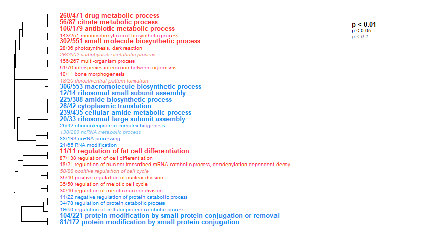

High flow + no heat vs Low flow + no heat

Low flow + heat vs Low flow + no heat Biological Processes. Red is upregulated under heat and blue is upregulated under no heat

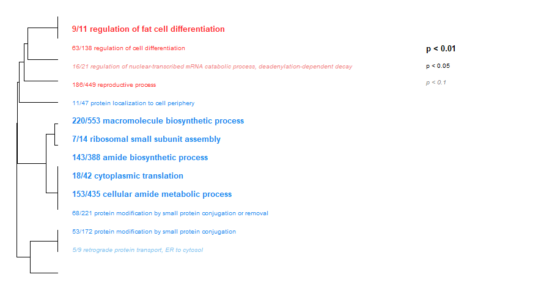

Low flow heat vs Low flow + no heat

# Conclusions:

We find that the gene expression of symbionts of A. cf. pulchra cluster differently than their hosts under the same conditions. Symbionts show different expression patterns under different flow environments when exposed to ambient temperature. This difference is categorized by an increase of “ribosomal” GO terms- which is associated with growth, under low flow and an increase of metabolism terms under high flow. Additionally, under high flow symbionts do not show differential expression between heat stress and no heat stress conditions, while under low flow they do. These differences are characterized by an increase in “ribosomal” GO terms under no heat stress and cell differentiation under heat stress. We also found incorporating colony in our deseq2 model decreases the number of differentially expressed genes in these comparisons (the other comparisons remain low). More analyses will need to be run to account for possible genotype specific expression patterns that could be driving some of these differences. Overall, our results suggest symbionts regulate their expression differently under different flow conditions, with the host possibly buffering expression under high flow which leads to our observed outcome of few differentially expressed genes between high flow no heat and high flow heat.